# Reproducable_research_assignment_1

Aya Abdelmonem

6 أغسطس، 2017

# Welcome to Reproducable Research Assignment_1

Here we are reading file into R and store data into new variable.

```r
Activity_data <- read.csv("C:/Users/dell/Desktop/myDataScienceWork/reproducable research/Reproducable_research_assignment_1/RepData_PeerAssessment1/activity/activity.csv")
```

We can take a look about these data and collect basic information about it .

```r
summary(Activity_data)
```

```
##      steps                date          interval
##  Min.   :  0.00   2012-10-01:  288   Min.   :   0.0
##  1st Qu.:  0.00   2012-10-02:  288   1st Qu.: 588.8
##  Median :  0.00   2012-10-03:  288   Median :1177.5
##  Mean   : 37.38   2012-10-04:  288   Mean   :1177.5
##  3rd Qu.: 12.00   2012-10-05:  288   3rd Qu.:1766.2
##  Max.   :806.00   2012-10-06:  288   Max.   :2355.0
##  NA's   :2304     (Other)   :15840
```

We can determine the first six rows in the dataset.

```r
head(Activity_data)
```

```
##   steps       date interval
## 1    NA 2012-10-01        0
## 2    NA 2012-10-01        5
## 3    NA 2012-10-01       10
## 4    NA 2012-10-01       15
## 5    NA 2012-10-01       20
## 6    NA 2012-10-01       25
```

To count the steps per day in Activity dataset

```r
steps_per_day <- aggregate(steps ~ date, data = Activity_data, sum, na.rm = TRUE)
```

To plot the total steps per day

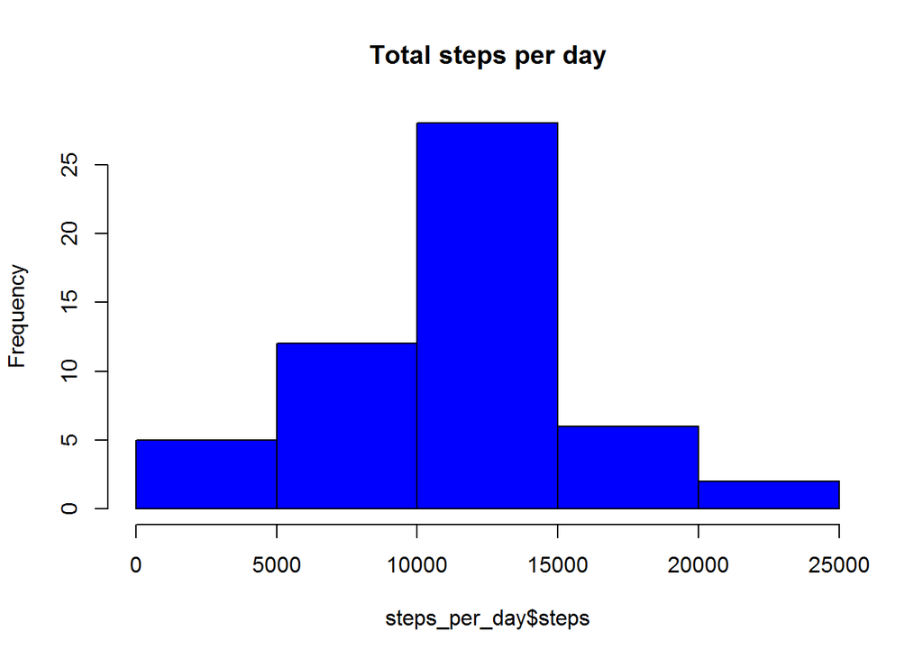

```r
hist(steps_per_day$steps, main = "Total steps per day", col = "blue")
```

Mean value of total steps per day is :

```r
mean(steps_per_day$steps)
```

```
## [1] 10766.19
```

Median value of total steps per day is :

```r
median(steps_per_day$steps)
```

```
## [1] 10765
```

To get the average of daily activity pattern ,

Make a time series plot (i.e. type = “l”) of the 5-minute interval (x-axis) and the average number of steps taken, averaged across all days (y-axis)

```r
avg_steps_time_series <- tapply(Activity_data$steps, Activity_data$interval, mean, na.rm = TRUE)
```

Plotting time series for daily activity pattern

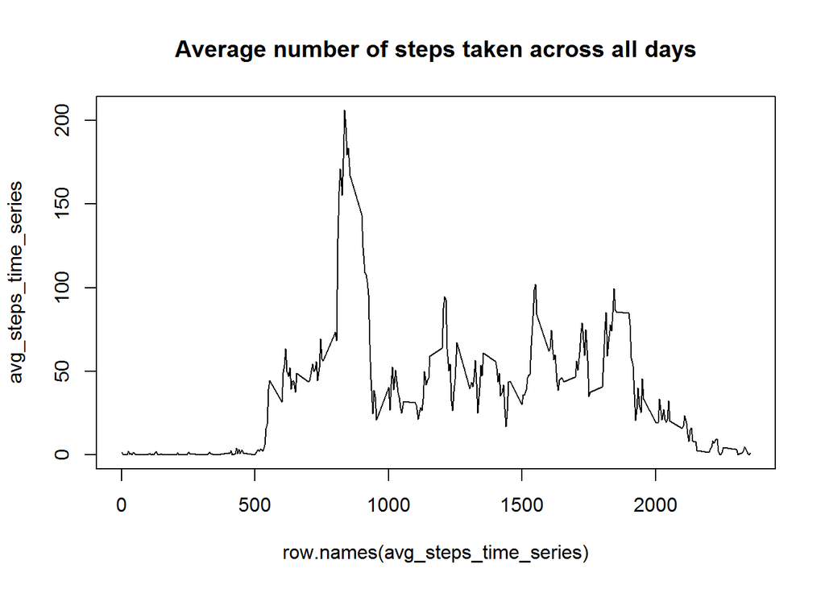

```r
plot(row.names(avg_steps_time_series), avg_steps_time_series, type = "l", main = "Average number of steps taken across all days")
```

We can determine the maximum number of steps of daily activity pattern :

```r
which.max(avg_steps_time_series)
```

```
## 835
## 104
```

To Impute missing values, we collect the total numebr of NA’S in dataset rows

```r
missing_values <- sum(is.na(Activity_data))
missing_values
```

```
## [1] 2304
```

This is a strategy to fill all the missing values in the dataset create a new dataset

```r
Activity_data2 <- Activity_data
```

```r
StepsAverage <- aggregate(steps ~ interval, data = Activity_data, FUN = mean)

fillNA <- numeric()

for (i in 1:nrow(Activity_data)) {

    obs <- Activity_data[i, ]

    if (is.na(obs$steps)) {

        steps <- subset(StepsAverage, interval == obs$interval)$steps

    }

    else
      {

        steps <- obs$steps
      }

    fillNA <- c(fillNA, steps)
}
```

And now ! we will fill the missing data in the new data set :

```r
Activity_data2$steps <- fillNA
```

Then we will calculate the total number of steps per day but with the new dataset calles activity_data2 which missing values filled in .

```r
steps_per_day2 <- aggregate(steps ~ date, data = Activity_data2, sum, na.rm = TRUE)
```

plotting the total numebr of steps per day with the new data set

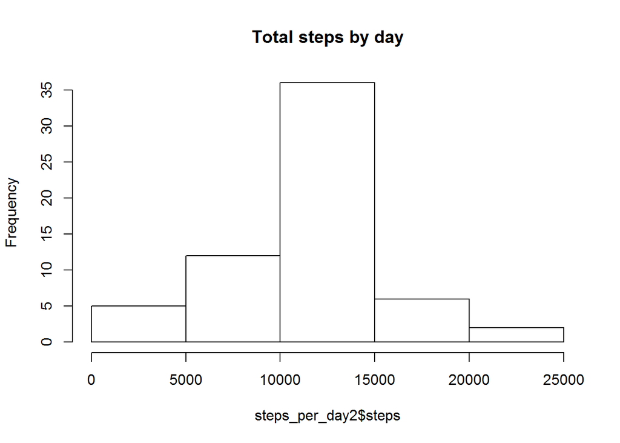

```r
hist(steps_per_day2$steps, main = "Total steps by day")
```

The mean of steps per day for the new dataset is :

```r
mean(steps_per_day2$steps)
```

```
## [1] 10766.19
```

The median of steps per day for the new dataset is :

```r
median(steps_per_day2$steps)
```

```
## [1] 10766.19
```

```r
library(magrittr)
library(dplyr)
```

[figure not shown]

[figure not shown]

[figure not shown]

[figure not shown]

```r
library(ggplot2)
library(lattice)
dates<- as.Date(Activity_data$date)
days<-weekdays(dates)

days<-ifelse(grepl("Saturday", days), "Weekend", days)
days<-ifelse(grepl("Sunday", days), "Weekend", days)
days<-ifelse(grepl("Monday", days), "Weekday", days)
days<-ifelse(grepl("Tuesday", days), "Weekday", days)
days<-ifelse(grepl("Wednesday", days), "Weekday", days)
days<-ifelse(grepl("Thursday", days), "Weekday", days)
days<-ifelse(grepl("Friday", days), "Weekday", days)
days<- as.factor(days)
Activity_data<-cbind(Activity_data,days)


intbydaytype <- Activity_data %>% group_by(interval, days) %>% summarise(steps = mean(steps))
xyplot(steps ~ interval | days, intbydaytype , type = "l", layout = c(1, 2),
    xlab = "Interval", ylab = "Number of steps")
```